# Weather Data

JcB

28/07/2015

# 1 Librairie weatherData

[source](http://cran.r-project.org/web/packages/weatherData/weatherData.pdf)

initialisation:

```r
library("weatherData")
```

Utilise: - le code s’une station météo sous la forme d’un sigle aéroportuaire: Strasbourg = LFST - la date du jour

# 2 Station météo

## 2.1 Alsace

- STRASBOURG/ENTZH **LFST**
- BALE/MULHOUSE **LFSB**
- COLMAR/MEYENHEIM **LFSC**

## 2.2 Damgan

- http://www.meteo-damgan.fr/ météo complète + horaires des marées
- indicatif de la station: IBRETAGN30

## 2.3 Aéroport de Vannes

- C’est le plus proche de Pluherlin
- indicatif: LFRV

# 3 Afficher la météo du jour

La méthode **getDetailedWeather** donne les infos le jour donné sous forme d’un dataframe.

- **opt_all_columns = TRUE** affiche toutes les infos disponibles par heure. Par défaut (FALSE) n’affiche que les températures.
- **opt_custom_columns** permet un choix personalisé des colonnes à afficher. Par défaut vaut FALSE. Si on met TRUE, il faut obligatoirement renseigner l’option _custom_columns-.
- **custom_columns** vecteur d’INTEGER inqiquant le n° de la colonne à afficher. La première colonne (*Time*) est toujours affichée. Il est donc inutile de le péciser. La numérotation effective commence à 2. Par exemple or afficher la température et la pression: names(getDetailedWeather(“LFST”, “2014-06-10”, opt_custom_columns=TRUE, custom_columns=c(2,5) ))

```r
today <- format(Sys.time(), "%Y-%m-%d")
station <- "LFST"

checkDataAvailability(station_id = "LFST", check_date = today)
```

```
## Getting data from:
##  http://www.wunderground.com/history/airport/LFST/2015/7/28/DailyHistory.html?format=1
##
## The following columns are available for:2015-07-28
```

```
##  [1] "TimeCEST"              "TemperatureC"
##  [3] "Dew_PointC"            "Humidity"
##  [5] "Sea_Level_PressurehPa" "VisibilityKm"
##  [7] "Wind_Direction"        "Wind_SpeedKm_h"
##  [9] "Gust_SpeedKm_h"        "Precipitationmm"
## [11] "Events"                "Conditions"
## [13] "WindDirDegrees"        "DateUTC"
```

```
## Checking Data Availability For LFST
## Found Records for 2015-07-28
## Data is Available
```

```
## [1] 1
```

```r
station <- "LFST"# strasbourg

t <- getDetailedWeather(station, today, opt_all_columns = TRUE)
names(t)
```

```
##  [1] "Time"                  "TimeCEST"
##  [3] "TemperatureC"          "Dew_PointC"
##  [5] "Humidity"              "Sea_Level_PressurehPa"
##  [7] "VisibilityKm"          "Wind_Direction"
##  [9] "Wind_SpeedKm_h"        "Gust_SpeedKm_h"
## [11] "Precipitationmm"       "Events"
## [13] "Conditions"            "WindDirDegrees"
## [15] "DateUTC"
```

```r
str(t)
```

```
## 'data.frame':    60 obs. of  15 variables:
##  $ Time                 : POSIXct, format: "2015-07-28 00:00:00" "2015-07-28 00:00:00" ...
##  $ TimeCEST             : chr  "12:00 AM" "12:00 AM" "12:30 AM" "1:00 AM" ...
##  $ TemperatureC         : num  19 19 20 20 20 21 20 21 20 20 ...
##  $ Dew_PointC           : num  10 10 10 11 11 11 11 11 11 11 ...
##  $ Humidity             : int  44 56 52 48 56 53 44 53 56 47 ...
##  $ Sea_Level_PressurehPa: int  1009 1009 1009 1009 1009 1009 1009 1009 1009 1009 ...
##  $ VisibilityKm         : num  60 -9999 10 60 10 ...
##  $ Wind_Direction       : chr  "SSW" "SSW" "SSW" "SSW" ...
##  $ Wind_SpeedKm_h       : num  13 13 13 11.1 11.1 24.1 18.5 18.5 16.7 14.8 ...
##  $ Gust_SpeedKm_h       : chr  "" "-" "-" "" ...
##  $ Precipitationmm      : chr  "" "N/A" "N/A" "" ...
##  $ Events               : logi  NA NA NA NA NA NA ...
##  $ Conditions           : chr  "Clear" "Clear" "Overcast" "Clear" ...
##  $ WindDirDegrees       : int  210 210 200 210 210 250 250 250 280 270 ...
##  $ DateUTC              : chr  "2015-07-27 22:00:00" "2015-07-27 22:00:00" "2015-07-27 22:30:00" "2015-07-27 23:00:00" ...
```

```r
head(t)
```

```
##                  Time TimeCEST TemperatureC Dew_PointC Humidity
## 1 2015-07-28 00:00:00 12:00 AM           19         10       44
## 2 2015-07-28 00:00:00 12:00 AM           19         10       56
## 3 2015-07-28 00:30:00 12:30 AM           20         10       52
## 4 2015-07-28 01:00:00  1:00 AM           20         11       48
## 5 2015-07-28 01:00:00  1:00 AM           20         11       56
## 6 2015-07-28 01:30:00  1:30 AM           21         11       53
##   Sea_Level_PressurehPa VisibilityKm Wind_Direction Wind_SpeedKm_h
## 1                  1009           60            SSW           13.0
## 2                  1009        -9999            SSW           13.0
## 3                  1009           10            SSW           13.0
## 4                  1009           60            SSW           11.1
## 5                  1009           10            SSW           11.1
## 6                  1009           10            WSW           24.1
##   Gust_SpeedKm_h Precipitationmm Events Conditions WindDirDegrees
## 1                                    NA      Clear            210
## 2              -             N/A     NA      Clear            210
## 3              -             N/A     NA   Overcast            200
## 4                                    NA      Clear            210
## 5              -             N/A     NA   Overcast            210
## 6              -             N/A     NA   Overcast            250
##               DateUTC
## 1 2015-07-27 22:00:00
## 2 2015-07-27 22:00:00
## 3 2015-07-27 22:30:00
## 4 2015-07-27 23:00:00
## 5 2015-07-27 23:00:00
## 6 2015-07-27 23:30:00
```

```r
t[, c("TimeCEST", "TemperatureC","Sea_Level_PressurehPa")]
```

```
##    TimeCEST TemperatureC Sea_Level_PressurehPa
## 1  12:00 AM           19                  1009
## 2  12:00 AM           19                  1009
## 3  12:30 AM           20                  1009
## 4   1:00 AM           20                  1009
## 5   1:00 AM           20                  1009
## 6   1:30 AM           21                  1009
## 7   2:00 AM           20                  1009
## 8   2:00 AM           21                  1009
## 9   2:30 AM           20                  1009
## 10  3:00 AM           20                  1009
## 11  3:00 AM           20                  1009
## 12  3:30 AM           20                  1009
## 13  4:00 AM           20                  1009
## 14  4:00 AM           20                  1009
```

[output cut: 46 more lines]

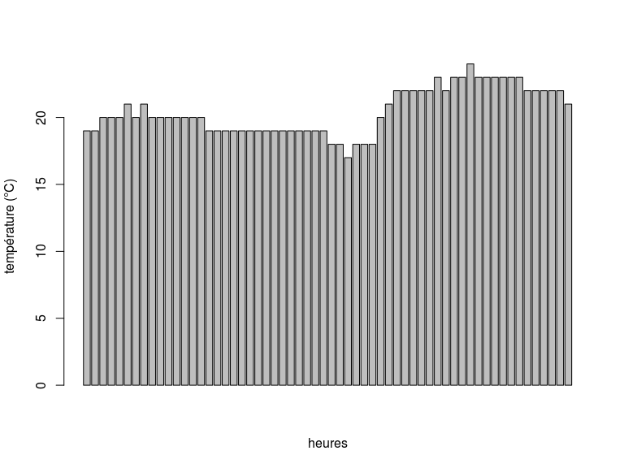

[output not shown]

```r
barplot(t[,3], ylab = "température (°C)", xlab = "heures")
```

# 4 Température du mois

```r
library(xts)

start_date <- "2015-06-01"
end_date <- "2015-07-28"

# Strasbourg
station = "LFST"
tm <- getWeatherForDate(station, start_date=start_date, end_date=end_date, opt_all_columns = TRUE)
```

```
##  [1] "CEST"                       "Max_TemperatureC"
##  [3] "Mean_TemperatureC"          "Min_TemperatureC"
##  [5] "Dew_PointC"                 "MeanDew_PointC"
##  [7] "Min_DewpointC"              "Max_Humidity"
##  [9] "Mean_Humidity"              "Min_Humidity"
## [11] "Max_Sea_Level_PressurehPa"  "Mean_Sea_Level_PressurehPa"
## [13] "Min_Sea_Level_PressurehPa"  "Max_VisibilityKm"
## [15] "Mean_VisibilityKm"          "Min_VisibilitykM"
## [17] "Max_Wind_SpeedKm_h"         "Mean_Wind_SpeedKm_h"
## [19] "Max_Gust_SpeedKm_h"         "Precipitationmm"
## [21] "CloudCover"                 "Events"
## [23] "WindDirDegrees"
##  [1] "Date"                       "CEST"
##  [3] "Max_TemperatureC"           "Mean_TemperatureC"
##  [5] "Min_TemperatureC"           "Dew_PointC"
##  [7] "MeanDew_PointC"             "Min_DewpointC"
##  [9] "Max_Humidity"               "Mean_Humidity"
## [11] "Min_Humidity"               "Max_Sea_Level_PressurehPa"
## [13] "Mean_Sea_Level_PressurehPa" "Min_Sea_Level_PressurehPa"
## [15] "Max_VisibilityKm"           "Mean_VisibilityKm"
## [17] "Min_VisibilitykM"           "Max_Wind_SpeedKm_h"
## [19] "Mean_Wind_SpeedKm_h"        "Max_Gust_SpeedKm_h"
## [21] "Precipitationmm"            "CloudCover"
## [23] "Events"                     "WindDirDegrees"
```

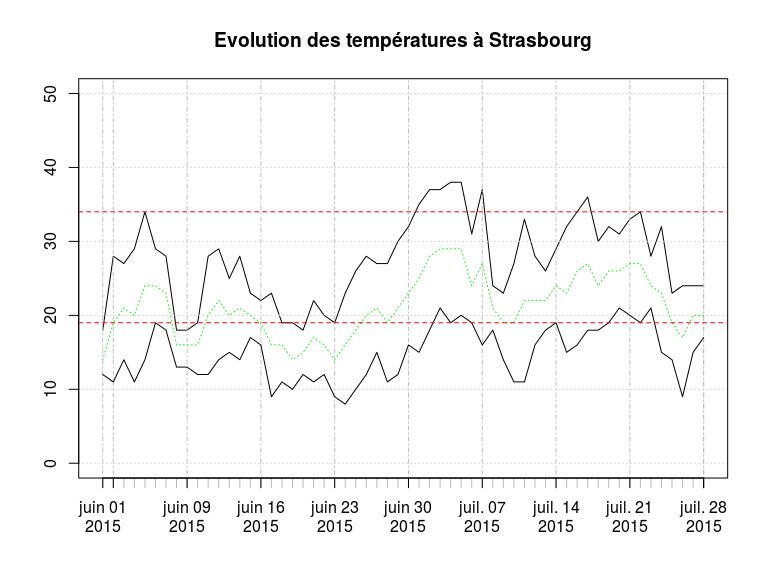

```r
xt <- xts(tm[, c(3, 4, 5)], order.by = tm[,1])
plot(xt[,1], ylim = c(0,50), main = "Evolution des températures à Strasbourg")
lines(xt[,3], ylim = c(0,50))
lines(xt[,2], ylim = c(0,50), lty = 3, col = "green")
abline(h = 34, lty = 2, col = "red")
abline(h = 19, lty = 2, col = "red")
```

```r
# Mulhouse
station = "LFSB"
tm <- getWeatherForDate(station, start_date=start_date, end_date=end_date, opt_all_columns = TRUE)
```

```
##  [1] "CEST"                       "Max_TemperatureC"
##  [3] "Mean_TemperatureC"          "Min_TemperatureC"
##  [5] "Dew_PointC"                 "MeanDew_PointC"
##  [7] "Min_DewpointC"              "Max_Humidity"
##  [9] "Mean_Humidity"              "Min_Humidity"
## [11] "Max_Sea_Level_PressurehPa"  "Mean_Sea_Level_PressurehPa"
## [13] "Min_Sea_Level_PressurehPa"  "Max_VisibilityKm"
## [15] "Mean_VisibilityKm"          "Min_VisibilitykM"
## [17] "Max_Wind_SpeedKm_h"         "Mean_Wind_SpeedKm_h"
## [19] "Max_Gust_SpeedKm_h"         "Precipitationmm"
## [21] "CloudCover"                 "Events"
## [23] "WindDirDegrees"
##  [1] "Date"                       "CEST"
##  [3] "Max_TemperatureC"           "Mean_TemperatureC"
##  [5] "Min_TemperatureC"           "Dew_PointC"
##  [7] "MeanDew_PointC"             "Min_DewpointC"
##  [9] "Max_Humidity"               "Mean_Humidity"
## [11] "Min_Humidity"               "Max_Sea_Level_PressurehPa"
## [13] "Mean_Sea_Level_PressurehPa" "Min_Sea_Level_PressurehPa"
## [15] "Max_VisibilityKm"           "Mean_VisibilityKm"
## [17] "Min_VisibilitykM"           "Max_Wind_SpeedKm_h"
## [19] "Mean_Wind_SpeedKm_h"        "Max_Gust_SpeedKm_h"
## [21] "Precipitationmm"            "CloudCover"
## [23] "Events"                     "WindDirDegrees"
```

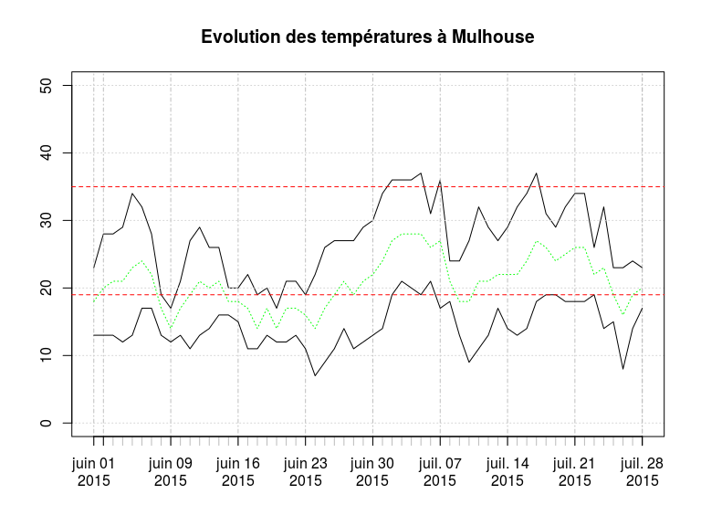

```r
xt <- xts(tm[, c(3, 4, 5)], order.by = tm[,1])
plot(xt[,1], ylim = c(0,50), main = "Evolution des températures à Mulhouse")
lines(xt[,3], ylim = c(0,50))
lines(xt[,2], ylim = c(0,50), lty = 3, col = "green")
abline(h = 35, lty = 2, col = "red")
abline(h = 19, lty = 2, col = "red")
```

```r
# Colmar
station = "LFSC"
tm <- getWeatherForDate(station, start_date=start_date, end_date=end_date, opt_all_columns = TRUE)
```

```
##  [1] "CEST"                       "Max_TemperatureC"
##  [3] "Mean_TemperatureC"          "Min_TemperatureC"
##  [5] "Dew_PointC"                 "MeanDew_PointC"
##  [7] "Min_DewpointC"              "Max_Humidity"
##  [9] "Mean_Humidity"              "Min_Humidity"
## [11] "Max_Sea_Level_PressurehPa"  "Mean_Sea_Level_PressurehPa"
## [13] "Min_Sea_Level_PressurehPa"  "Max_VisibilityKm"
## [15] "Mean_VisibilityKm"          "Min_VisibilitykM"
## [17] "Max_Wind_SpeedKm_h"         "Mean_Wind_SpeedKm_h"
## [19] "Max_Gust_SpeedKm_h"         "Precipitationmm"
## [21] "CloudCover"                 "Events"
## [23] "WindDirDegrees"
##  [1] "Date"                       "CEST"
##  [3] "Max_TemperatureC"           "Mean_TemperatureC"
##  [5] "Min_TemperatureC"           "Dew_PointC"
##  [7] "MeanDew_PointC"             "Min_DewpointC"
##  [9] "Max_Humidity"               "Mean_Humidity"
## [11] "Min_Humidity"               "Max_Sea_Level_PressurehPa"
## [13] "Mean_Sea_Level_PressurehPa" "Min_Sea_Level_PressurehPa"
## [15] "Max_VisibilityKm"           "Mean_VisibilityKm"
## [17] "Min_VisibilitykM"           "Max_Wind_SpeedKm_h"
## [19] "Mean_Wind_SpeedKm_h"        "Max_Gust_SpeedKm_h"
## [21] "Precipitationmm"            "CloudCover"
## [23] "Events"                     "WindDirDegrees"
```

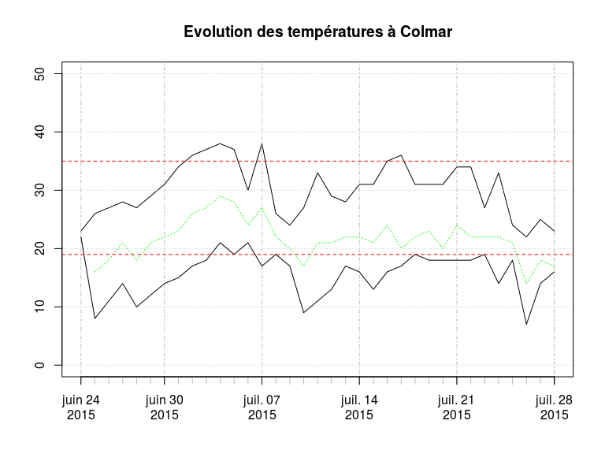

```r
xt <- xts(tm[, c(3, 4, 5)], order.by = tm[,1])
plot(xt[,1], ylim = c(0,50), main = "Evolution des températures à Colmar")
lines(xt[,3], ylim = c(0,50))
lines(xt[,2], ylim = c(0,50), lty = 3, col = "green")
abline(h = 35, lty = 2, col = "red")
abline(h = 19, lty = 2, col = "red")
```

# 5 Quand déclare-t-on l’état de canicule ?

Par définition, on parle de canicule lorsque les températures observées sont élevées jour et nuit pendant trois jours d’affilée. « Plus il fait chaud le jour, plus on fatigue. Plus il fait chaud la nuit, moins on récupère », explique Météo France.

L’organisme météorologique a déterminé des seuils d’alerte à partir de trente années de données quotidiennes de mortalité et de différents indicateurs météorologiques. Il les compare à des indicateurs biométéorologiques calculés à partir des températures minimales et maximales quotidiennes, en fonction de ses prévisions.

Les diverses régions de France étant plus ou moins habituées et donc adaptées à la chaleur, les seuils d’alertes ne sont pas les mêmes partout. Ainsi, Météo France estime que la canicule sera avérée dans les Deux-Sèvres lorsque des températures minimales de 35 °C le jour et 20 °C la nuit seront observées. La Haute-Loire, elle, sera considérée en canicule lorsque les températures dépasseront 32 °C le jour et 18 °C la nuit. A Paris, ces seuils sont de 31 °C le jour et 21 °C la nuit, ou encore à Marseille de 35 °C le jour et 24 °C la nuit.

En savoir plus sur http://www.lemonde.fr/les-decodeurs/article/2015/07/01/comment-le-plan-national-canicule-fonctionne-t-il_4665550_4355770.html#lswgUrOuwTvwuW6g.99

Jour de canicule: 2015-07-04

| Département | Jour | Nuit |
| --- | --- | --- |
| Bas-Rhin | 34 | 19 |
| Haut-Rhin | 35 | 19 |
| Moselle | 34 | 19 |
| Vosges | 34 | 18 |
| Meurthe&M | 34 | 18 |